# Busca Sistemática de Literatura com R

Author

Mário O. de Menezes

# Introdução

Realizar uma busca sistemática de literatura científica é normalmente um processo que exige grande esforço, pode durar bastante tempo, consumindo tempo precioso.

O software estatístico R possui muitas ferramentas apropriadas para se fazer Revisão Sistemática e também Meta-análise. Dentre estas ferramentas temos o pacote `litsearchr`.

Neste tutorial, vamos utilizar vários pacotes para automatizar e facilitar o processo de Revisão Sistemática:

- `litsearchr` – para uma abordagem automática para identificar os termos de busca para revisões sistemáticas, usando redes de co-ocorrência de palavras chaves.
- `easyPubMed` – que simplifica o uso da API do PubMed para consulta e extração de dados dos artigos.
- `stopwords` – base de dados de “Stopwords”, do *Stopwords ISO Dataset* que é a coleção mais abrangente de *stopwords* para múltiplos idiomas.
- `igraph` – para análise da rede (este pacote já é uma dependência do pacote `litsearchr`, mas tem muitas outras funções independentes).
- `ggplot2`, `ggraph` e `ggrepel` para gráficos.

# Carregar ou instalar os pacotes

```r
# litsearchr isn't yet on CRAN, need to install from github
if (require(litsearchr)) remotes::install_github("elizagrames/litsearchr", ref = "main")

# Packages to load/install
packages <- c(
  "easyPubMed",
  "litsearchr", "stopwords", "igraph",
  "ggplot2", "ggraph", "ggrepel"
)

# Install packages not yet installed
installed_packages <- packages %in% rownames(installed.packages())
if (any(installed_packages == FALSE)) {
  install.packages(packages[!installed_packages])
}

# Load packages
lapply(packages, library, character.only = TRUE)
```

[output not shown]

# Consultar PubMed para a literatura relevante

## Consulta simples

Para demonstrar o workflow básico de uma única consulta. Vamos definir uma expressão de busca na variável `term`:

```r
term <- '((((((((((("animal*"[All Fields] OR "in vivo"[All Fields] OR "preclinical"[All Fields]) AND "Phototherapy"[All Fields]) OR "Photobiomodulation"[All Fields] OR "Light therapy"[All Fields] OR "LED therapy"[All Fields] OR "Light-emitting diode"[All Fields] OR "Laser therapy"[All Fields]) AND "stem cells"[All Fields]) OR "tissue engineering"[All Fields] OR "cell therapy"[All Fields] OR "cellular therapy"[All Fields] OR "regenerative medicine"[All Fields]) NOT "Review"[Publication Type]) NOT "letter"[Publication Type]) NOT "in vitro techniques"[MeSH Terms]) NOT "clinical trials as topic"[MeSH Terms]) NOT "clinical trial"[Publication Type]) NOT ("veterinary medicine"[MeSH Terms] OR ("veterinary"[All Fields] AND "medicine"[All Fields]) OR "veterinary medicine"[All Fields])) NOT ("veterinary"[MeSH Subheading] OR "veterinary"[All Fields])'
```

Esta expressão de busca foi construída a partir do artigo “Could Light-Based Technologies Improve Stem Cell Therapy for Skin Wounds? A Systematic Review and Meta-Analysis of Preclinical Studies”, publicado por Tania M. Yoshimura, Fernanda V. Cabral, Fábio P. Sellera, Lorena Pozzo, Martha S. Ribeiro.

A expressão original citada no artigo é:

```
Animal* OR “in vivo” OR “preclinical” AND “Phototherapy” OR “Photobiomodulation” OR “Light therapy” OR “LED therapy” OR “Light-emitting diode” OR “Laser therapy” AND “stem cells” OR “tissue engineering” OR “cell therapy” OR “cellular therapy” OR “regenerative medicine”
```

Depois foram adicionados as remoções indicados no texto do artigo, resultando na expressão indicada.

Vamos buscar os `ids` na PubMed:

```r
pmid_list <- easyPubMed::get_pubmed_ids(term)
```

Agora crianos um `data.frame` com os campos principais:

```r
pm_xml <- easyPubMed::fetch_pubmed_data(pmid_list, encoding = "ASCII")
pm_df <- easyPubMed::table_articles_byAuth(pubmed_data = pm_xml,
                                           included_authors = "all",
                                           getKeywords = TRUE,
                                           max_chars = 500)
```

```
Processing PubMed data .................................................. done!
```

```r
as.data.frame(lapply(head(pm_df[c("pmid", "doi", "jabbrv", "keywords", "abstract")]), substr, start = 1, stop = 30))
```

```
      pmid                    doi                jabbrv
1 37218435  10.1089/ars.2022.0166 Antioxid Redox Signal
2 37218435  10.1089/ars.2022.0166 Antioxid Redox Signal
3 37218343 10.1093/humrep/dead090            Hum Reprod
4 37218343 10.1093/humrep/dead090            Hum Reprod
5 37218343 10.1093/humrep/dead090            Hum Reprod
6 37218343 10.1093/humrep/dead090            Hum Reprod
                        keywords                       abstract
1                           <NA> A cell plays its roles through
2                           <NA> A cell plays its roles through
3 chromosomal mosaicism; copy nu Can multiple-site low-pass gen
4 chromosomal mosaicism; copy nu Can multiple-site low-pass gen
5 chromosomal mosaicism; copy nu Can multiple-site low-pass gen
6 chromosomal mosaicism; copy nu Can multiple-site low-pass gen
```

# Extraindo os termos dos dados recuperados

```r
# Extract terms from title
pm_terms_title <- litsearchr::extract_terms(text = pm_df[,"title"],
                                            method = "fakerake", min_freq = 3, min_n = 2,
                                            stopwords = stopwords::data_stopwords_stopwordsiso$en)

# Extract terms from keywords
pm_terms_keywords <- litsearchr::extract_terms(keywords = trimws(unlist(strsplit(pm_df[,"keywords"], ";"))),
                                               method = "tagged", min_freq = 3, min_n = 1, max_n = 5)

# Pool the extracted terms together
pm_terms <- c(pm_terms_title, pm_terms_keywords)
pm_terms <- pm_terms[!duplicated(pm_terms)]
```

# Criação da rede de co-ocorrência

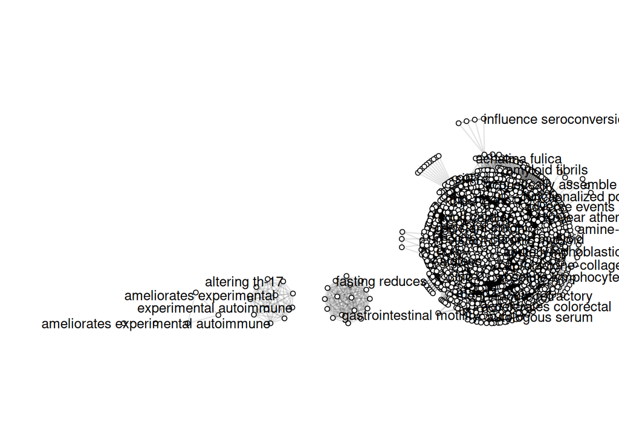

```r
# Create Co-Occurrence Network
pm_docs <- paste(pm_df[, "title"], pm_df[, "abstract"]) # we will consider title and abstract of each article to represent the article's "content"
pm_dfm <- litsearchr::create_dfm(elements = pm_docs, features = pm_terms) # document-feature matrix
pm_coocnet <- litsearchr::create_network(pm_dfm, min_studies = 3)

ggraph(pm_coocnet, layout = "stress") +
  coord_fixed() +
  expand_limits(x = c(-3, 3)) +
  geom_edge_link(aes(alpha = weight)) +
  geom_node_point(shape = "circle filled", fill = "white") +
  geom_node_text(aes(label = name), hjust = "outward", check_overlap = TRUE) +
  guides(edge_alpha = "none") +
  theme_void()
```

# Podar a rede baseado na força do nó

## Computar a força do nó

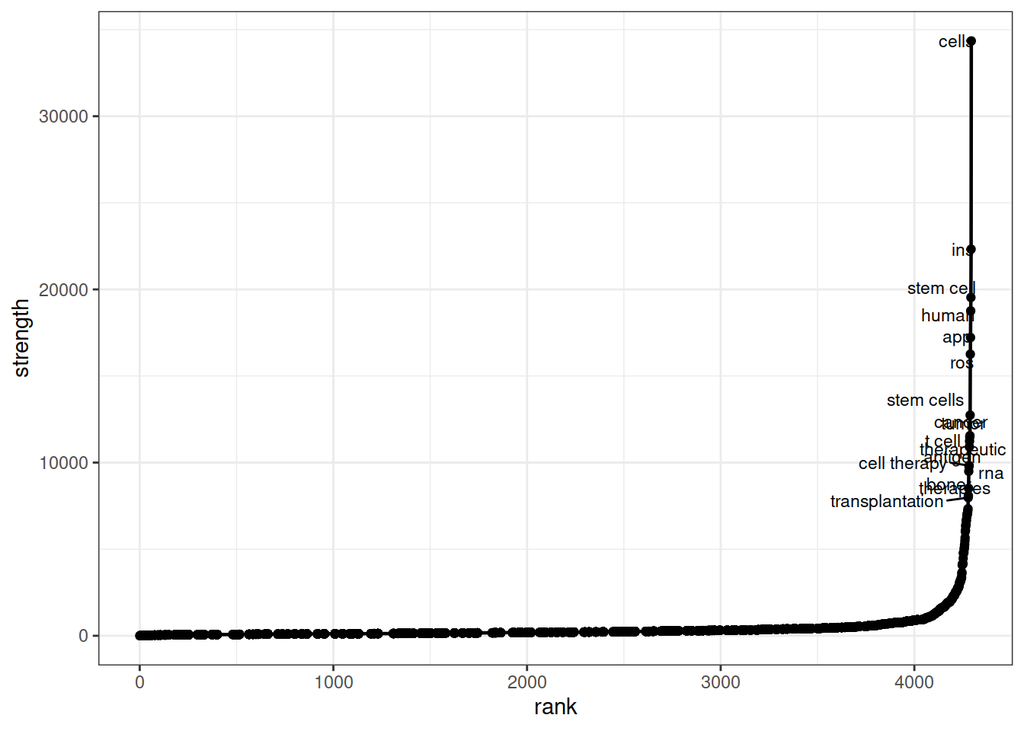

```r
# Prune the Network based on node strength
pm_node_strength <- igraph::strength(pm_coocnet)
pm_node_rankstrenght <- data.frame(term = names(pm_node_strength), strength = pm_node_strength, row.names = NULL)
pm_node_rankstrenght$rank <- rank(pm_node_rankstrenght$strength, ties.method = "min")
pm_node_rankstrenght <- pm_node_rankstrenght[order(pm_node_rankstrenght$rank),]

pm_plot_strenght <-
  ggplot(pm_node_rankstrenght, aes(x = rank, y = strength, label = term)) +
  geom_line(lwd = 0.8) +
  geom_point() +
  ggrepel::geom_text_repel(size = 3, hjust = "right", nudge_y = 3, max.overlaps = 30) +
  theme_bw()
pm_plot_strenght
```

## Podar baseado no critério escolhido

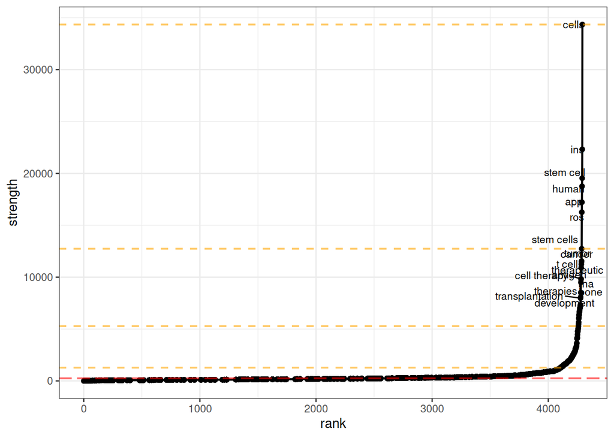

```r
# Cumulatively - retain a certain proportion (e.g. 80%) of the total strength of the network of search terms
pm_cutoff_cum <- litsearchr::find_cutoff(pm_coocnet, method = "cumulative", percent = 0.8)
# Changepoints - certain points along the ranking of terms where the strength of the next strongest term is much greater than that of the previous one
pm_cutoff_change <- litsearchr::find_cutoff(pm_coocnet, method = "changepoint", knot_num = 3)

pm_plot_strenght +
  geom_hline(yintercept = pm_cutoff_cum, color = "red", lwd = 0.7, linetype = "longdash", alpha = 0.6) +
  geom_hline(yintercept = pm_cutoff_change, color = "orange", lwd = 0.7, linetype = "dashed", alpha = 0.6)
```

```r
pm_cutoff_crit <- pm_cutoff_change[which.min(abs(pm_cutoff_change - pm_cutoff_cum))]  # e.g. nearest cutpoint to cumulative criterion (cumulative produces one value, changepoints may be many)

pm_selected_terms <- litsearchr::get_keywords(litsearchr::reduce_graph(pm_coocnet, pm_cutoff_crit))
```

```r
pm_selected_terms
```

```
  [1] "acute myeloid"                    "acute myeloid leukemia"
  [3] "antigen receptor"                 "b-cell lymphoma"
  [5] "breast cancer"                    "cancer cells"
  [7] "cellular matrix"                  "chimeric antigen"
  [9] "chimeric antigen receptor"        "clinical applications"
 [11] "clinical trial"                   "cytokine release"
 [13] "cytokine release syndrome"        "derived mesenchymal"
 [15] "extracellular matrix"             "extracellular vesicles"
 [17] "growth factor"                    "human umbilical"
 [19] "immune cells"                     "induced pluripotent"
 [21] "mechanical properties"            "mesenchymal stromal"
 [23] "mesenchymal stromal cells"        "mouse model"
 [25] "multiple myeloma"                 "myeloid leukemia"
 [27] "patients treated"                 "reactive oxygen"
 [29] "regenerative medicine"            "release syndrome"
```

[output cut: 79 more lines]

Com estes termos, procedemos uma análise manual para excluir aqueles que não interessam e agrupar os restantes; um agrupamento típico na área da saúde é:

- tipo de estudo (*design*);
- tipo de intervenção;
- desordem/sintoma;
- população.

Por exemplo, pode-se excluir termos que indiquem uma população que não é de interesse da pesquisa, ou que restrinjam a população indevidamente.

# Agrupamento manual dos termos

```r
# Só exemplo de como fazer o agrupamento. Não reflete os termos acima.

pm_selected_terms <- pm_selected_terms[-c(18, 19, 20, 32, 22, 25, 30)] # exclude terms

# Manual grouping into clusters - for more rigorous search we will need a combination of OR and AND operators
design <- pm_selected_terms[c(1:3, 11:15, 18, 19, 23, 25)]
intervention <- pm_selected_terms[c(4, 9, 10, 17, 21)]
disorder <- pm_selected_terms[c(5:8, 16, 20, 22, 24)]

# all.equal(length(pm_selected_terms),
#   sum(length(design), length(intervention), length(disorder))
# )  # check that we grouped all terms

pm_gruped_selected_terms <- list(
  design = design,
  intervention = intervention,
  disorder = disorder
)
```

# Automaticamente escreve a nova string de busca

```r
# Write the search
litsearchr::write_search(
  pm_gruped_selected_terms,
  languages = "English",
  exactphrase = TRUE,
  stemming = FALSE,
  closure = "left",
  writesearch = FALSE
)
```

```
[1] "English is written"
```

[output not shown]